# Lesson 5

### Multivariate Data

Notes: We will learn how to evaluate 3 or more variables at the same time.

### Moira Perceived Audience Size Colored by Age

Notes: In her examination of audience size on Facebook, Moira added a third variable - age - to see if there was a pattern for perceived audience vs actual audience. There was not.

```r
dir()
```

```
## [1] "lesson5_student_files" "lesson5_student.rmd"   "nci.tsv"
## [4] "pseudo_facebook.tsv"   "scatterplotMatrix.pdf" "yogurt.csv"
```

### Third Qualitative Variable

Notes: Let’s create a data frame that summarizes the pf data frame by age and gender so we can plot and try to spot patterns in friend count.

```r
pf <- read.csv('pseudo_facebook.tsv', sep='\t')

library(dplyr)
```

```r
library(ggplot2)
library(gridExtra)
pf.fc_by_age_gender <- pf %>%
  filter(!is.na(gender)) %>%
  group_by(age, gender) %>%
  summarize(mean_friends = mean(friend_count), median_friends = median(as.numeric(friend_count)), n=n()) %>%
  arrange(age)

head(pf.fc_by_age_gender)
```

```
## Source: local data frame [6 x 5]
## Groups: age [3]
##
##     age gender mean_friends median_friends     n
##   <int> <fctr>        <dbl>          <dbl> <int>
## 1    13 female     259.1606          148.0   193
## 2    13   male     102.1340           55.0   291
## 3    14 female     362.4286          224.0   847
## 4    14   male     164.1456           92.5  1078
## 5    15 female     538.6813          276.0  1139
## 6    15   male     200.6658          106.5  1478
```

### Plotting Conditional Summaries

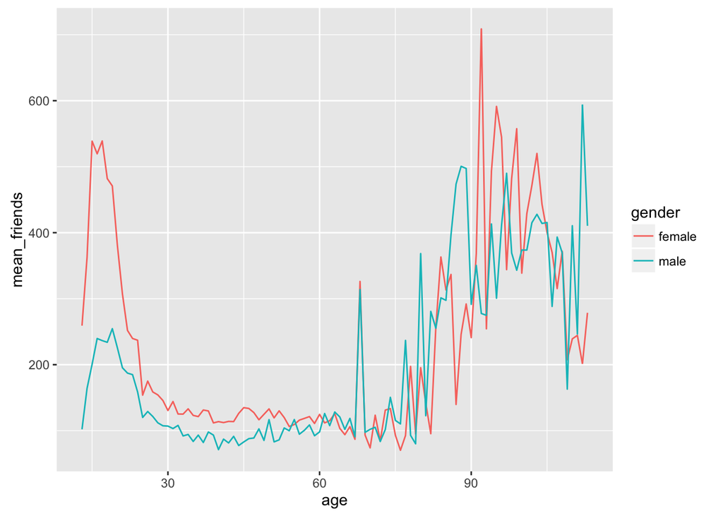

```r
ggplot(data=pf.fc_by_age_gender, aes(y=mean_friends, x = age)) +
  geom_line(aes(color=gender))
```

### Thinking in Ratios

Notes: Let’s figure out the ratios of the number of friends that females have compared to males.

### Wide and Long Format

Notes: We will be changing our data format from long to wide. The data is currently in long format because each age is listed twice - once for male and again for female. This will be changed to listing the age and gender just once and entering the mean value in another column.

### Reshaping Data

Notes: Let’s reshape the data from long to wide using the tidyr package.

```r
library(tidyr)

spread(subset(pf.fc_by_age_gender, select=c(age, gender, mean_friends)), gender, mean_friends)
```

```
## Source: local data frame [101 x 3]
## Groups: age [101]
##
##      age   female     male
## *  <int>    <dbl>    <dbl>
## 1     13 259.1606 102.1340
## 2     14 362.4286 164.1456
## 3     15 538.6813 200.6658
## 4     16 519.5145 239.6748
## 5     17 538.9943 236.4924
## 6     18 481.9794 233.9183
## 7     19 470.8007 254.5841
## 8     20 380.8244 225.5921
## 9     21 307.1064 195.3208
## 10    22 251.9152 187.2532
## # ... with 91 more rows
```

```r
pf.fc_by_age_gender.wide <- subset(pf.fc_by_age_gender[c('age', 'gender', 'median_friends')], !is.na(gender)) %>%
  spread(gender, median_friends) %>%
  mutate(ratio=female/male)

head(pf.fc_by_age_gender.wide)
```

```
## Source: local data frame [6 x 4]
## Groups: age [6]
##
##     age female  male    ratio
##   <int>  <dbl> <dbl>    <dbl>
## 1    13  148.0  55.0 2.690909
## 2    14  224.0  92.5 2.421622
## 3    15  276.0 106.5 2.591549
## 4    16  258.5 136.0 1.900735
## 5    17  245.5 125.0 1.964000
## 6    18  243.0 122.0 1.991803
```

Data can be converted from wide to long format by using the gather() function in tidyr. ***

### Ratio Plot

Notes: Let’s plot the ratio of females to males for friend count in relation to age.

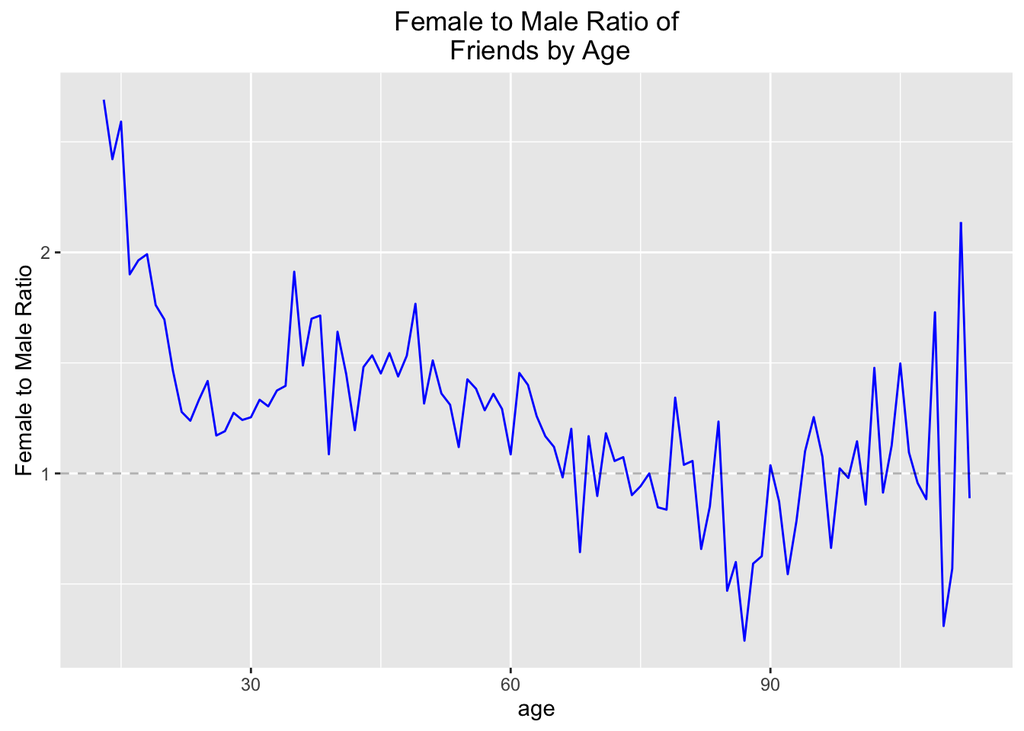

```r
ggplot(data=pf.fc_by_age_gender.wide, aes(x=age, y= ratio)) +
  geom_line(color='blue') +
  geom_hline(yintercept = 1, linetype = 2, alpha=0.3) +
  ylab('Female to Male Ratio') +
  ggtitle('Female to Male Ratio of\n Friends by Age')
```

### Third Quantitative Variable

Notes: We will now look at 4 variables simultaneously to see if the year that people joined Facebook has an effect on their overall friend count.

First, let’s create a variable called year_joined that uses the number of days from the variable “tenure” and the reference year 2014.

```r
pf$year_joined <- floor(2014-pf$tenure/365)
```

### Cut a Variable

Notes: It looks like the majority of the users joinedd after 2011. So we will create 4 “buckets” to add the data into 4 ranges.

(2004, 2009] (2009, 2011] (2011, 2012] (2012, 2014]

Parenthesis means exclude the year and bracket means to include the year.

```r
pf$year_joined.bucket <- cut(pf$year_joined, c(2004, 2009, 2011, 2012, 2014))
```

### Plotting it All Together

Notes: Now, let’s plot the median friends vs age count for each of the people in the year joined bucket

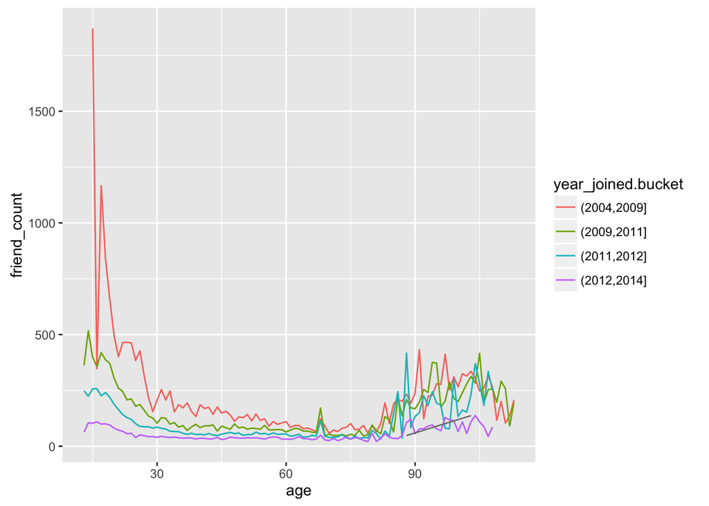

```r
ggplot(data=subset(pf, !is.na(gender)), aes(x=age, y=friend_count)) +
  geom_line(aes(color = year_joined.bucket), stat='summary', fun.y=median)
```

### Plot the Grand Mean

Notes: Let’s find the mean friends for each cohort and the grand mean of all of the data.

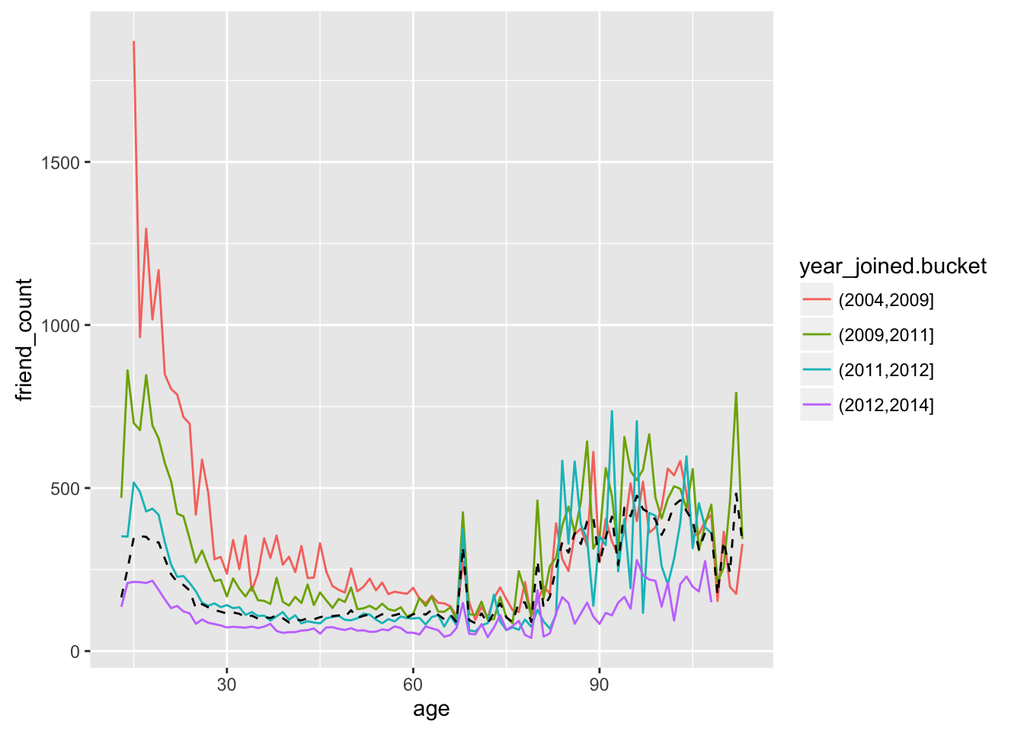

```r
ggplot(data=subset(pf, !is.na(year_joined.bucket)), aes(x=age, y=friend_count)) +
  geom_line(aes(color = year_joined.bucket), stat='summary', fun.y=mean) +
  geom_line(stat='summary',fun.y=mean, linetype = 2, color = 'black')
```

### Friending Rate

Notes: Let’s define the “Friending Rate” as the number of friends per day joined on Facebook.

```r
with(subset(pf, tenure >0), summary(friend_count/tenure))
```

```
##     Min.  1st Qu.   Median     Mean  3rd Qu.     Max.
##   0.0000   0.0775   0.2205   0.6096   0.5658 417.0000
```

### Friendships Initiated

Notes:

What is the median friend rate?

What is the maximum friend rate?

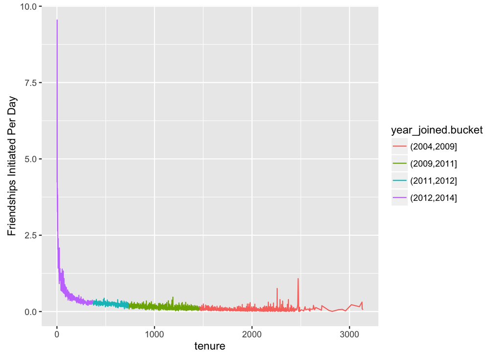

```r
ggplot(data=subset(pf, tenure >0), aes(x=tenure, y=friendships_initiated/tenure)) +
  geom_line(aes(color=year_joined.bucket), stat='summary', fun.y=mean) +
  ylab('Friendships Initiated Per Day')
```

### Bias-Variance Tradeoff Revisited

Notes: Since there is a lot of noise in the data, we will group the tenure in buckets. The next graphic shows the difference in noise when using buckets of different sizes.

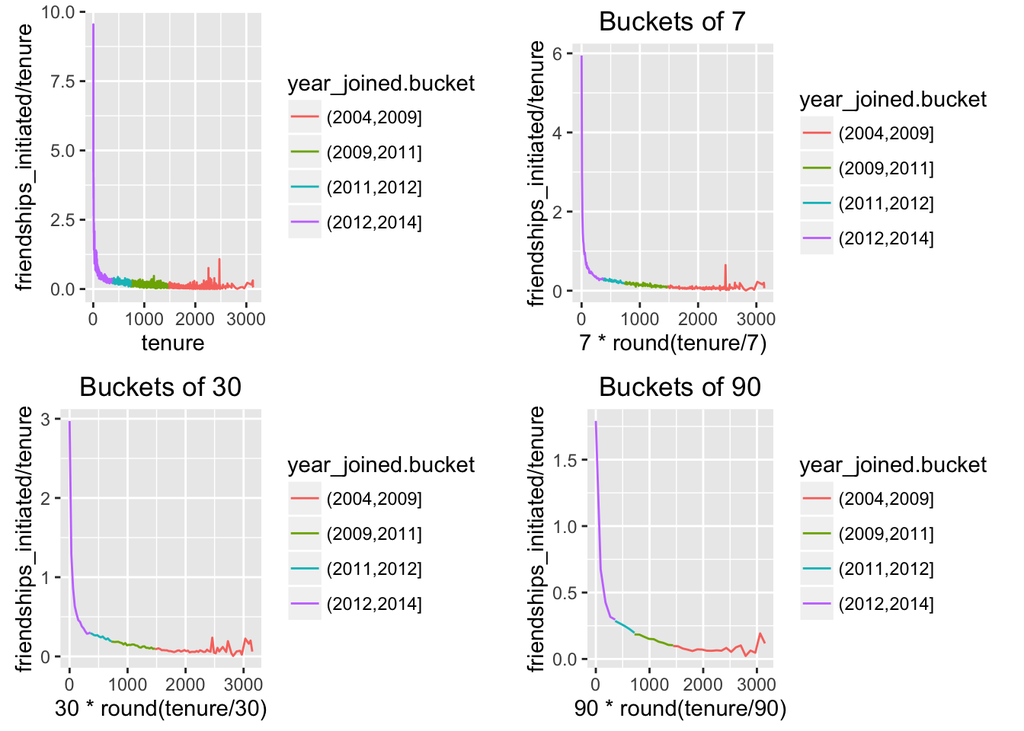

```r
p1 <- ggplot(aes(x = tenure, y = friendships_initiated / tenure),
       data = subset(pf, tenure >= 1)) +
  geom_line(aes(color = year_joined.bucket),
            stat = 'summary',
            fun.y = mean)

p2 <- ggplot(aes(x = 7 * round(tenure / 7), y = friendships_initiated / tenure),
       data = subset(pf, tenure > 0)) +
  geom_line(aes(color = year_joined.bucket),
            stat = "summary",
            fun.y = mean) +
  ggtitle('Buckets of 7')

p3 <- ggplot(aes(x = 30 * round(tenure / 30), y = friendships_initiated / tenure),
       data = subset(pf, tenure > 0)) +
  geom_line(aes(color = year_joined.bucket),
            stat = "summary",
            fun.y = mean) +
  ggtitle("Buckets of 30")

p4 <- ggplot(aes(x = 90 * round(tenure / 90), y = friendships_initiated / tenure),
       data = subset(pf, tenure > 0)) +
  geom_line(aes(color = year_joined.bucket),
            stat = "summary",
            fun.y = mean) +
  ggtitle('Buckets of 90')

grid.arrange(p1,p2,p3,p4, ncol =2)
```

We can also apply a smoother to reduce the noise in the graph.

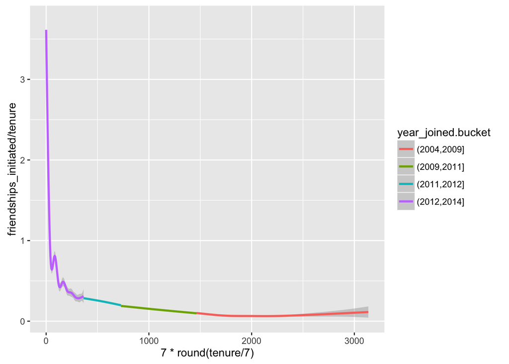

```r
ggplot(aes(x = 7 * round(tenure / 7), y = friendships_initiated / tenure),
       data = subset(pf, tenure > 0)) +
  geom_smooth(aes(color = year_joined.bucket))
```

### Sean’s NFL Fan Sentiment Study

Notes: Bias and variance in data are introduced when we try to reduce noise because they smooth out the lines. In exchange, we get data that is readible and understandable. The only caveat is that we have to keep the bias in mind.

### Introducing the Yogurt Data Set

Notes: Let’s work with the yogurt dataset to determine yogurt buying patterns. This dataset has several rows for each household that purchased yogurt.

### Histograms Revisited

Notes: Let’s bring in the yogurt dataset and explore it’s features

```r
yo <- read.csv('yogurt.csv')

str(yo)
```

```
## 'data.frame':    2380 obs. of  9 variables:
##  $ obs        : int  1 2 3 4 5 6 7 8 9 10 ...
##  $ id         : int  2100081 2100081 2100081 2100081 2100081 2100081 2100081 2100081 2100081 2100081 ...
##  $ time       : int  9678 9697 9825 9999 10015 10029 10036 10042 10083 10091 ...
##  $ strawberry : int  0 0 0 0 1 1 0 0 0 0 ...
##  $ blueberry  : int  0 0 0 0 0 0 0 0 0 0 ...
##  $ pina.colada: int  0 0 0 0 1 2 0 0 0 0 ...
##  $ plain      : int  0 0 0 0 0 0 0 0 0 0 ...
##  $ mixed.berry: int  1 1 1 1 1 1 1 1 1 1 ...
##  $ price      : num  59 59 65 65 49 ...
```

```r
yo$id <- factor(yo$id)
```

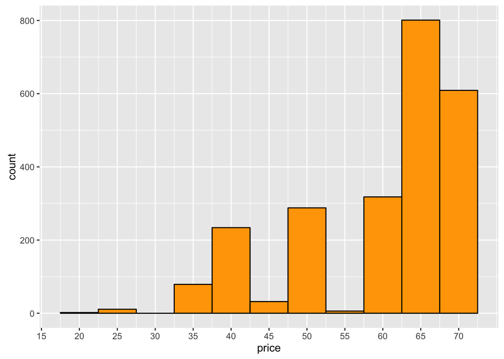

```r
ggplot(data=yo, aes(x=price)) +
  geom_histogram(color = 'black', fill = 'orange', binwidth = 5) +
  scale_x_continuous(breaks = seq(0,70, 5))
```

This is a very discrete data set with prices at certain numbers but no prices at the numbers immediately smaller or larger. ***

### Number of Purchases

Notes: Let’s count how many yogurts a household purchases at a time.

```r
yo$all.purchases <- transform(yo, all.purchases = strawberry+blueberry+pina.colada+plain+mixed.berry)$all.purchases
```

### Prices over Time

Notes: Let’s create a scatterplot of price vs time.

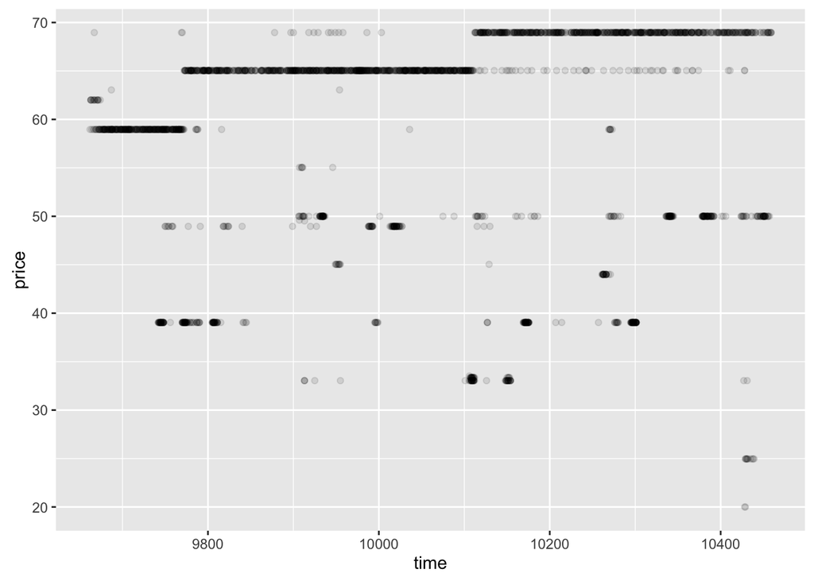

```r
ggplot(data=yo, aes(x=time, y=price)) +
  geom_point(alpha=1/10)
```

### Sampling Observations

Notes: We will take a sample of some of the households and see their spending over time.

### Looking at Samples of Households

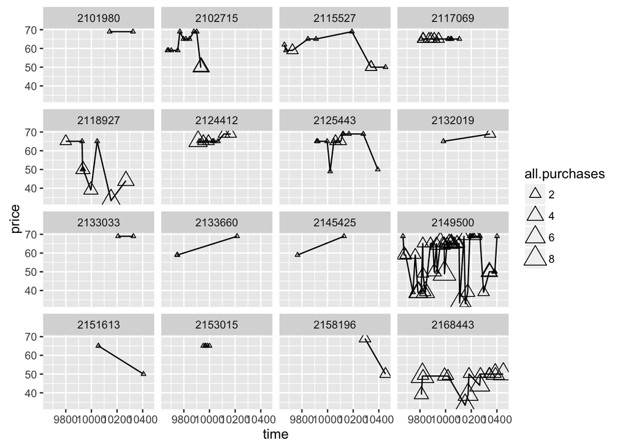

```r
set.seed(1310)
sample.id <- sample(levels(yo$id), 16)

ggplot(data=subset(yo, id %in% sample.id), aes(x=time, y=price)) +
  geom_line() +
  geom_point(aes(size=all.purchases), pch=2) +
  facet_wrap(~id)
```

### The Limits of Cross Sectional Data

Notes: The Facebook data is a snapshot of a single moment in time. Unlike the yogury database, it does not track the user’s activities over time. IF that data was available, we would be able to track the friendships initated over time vs tenure to see the bigger trend.

### Many Variables

Notes: We can plot many graphs at once to look at multiple variables at the same time.

### Scatterplot Matrix

Notes:

```r
library(GGally)
```

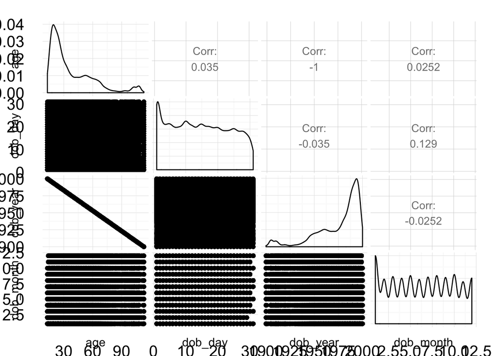

```r
theme_set(theme_minimal(20))

ggpairs(pf[ ,2:5])
```

### Even More Variables

Notes:

### Heat Maps

Notes:

```r
nci <- read.table("nci.tsv")
colnames(nci) <- c(1:64)
```

```r
library(reshape2)
nci.long.samp <- melt(as.matrix(nci[1:200,]))
names(nci.long.samp) <- c("gene", "case", "value")
head(nci.long.samp)
```

```
##   gene case  value
## 1    1    1  0.300
## 2    2    1  1.180
## 3    3    1  0.550
## 4    4    1  1.140
## 5    5    1 -0.265
## 6    6    1 -0.070
```

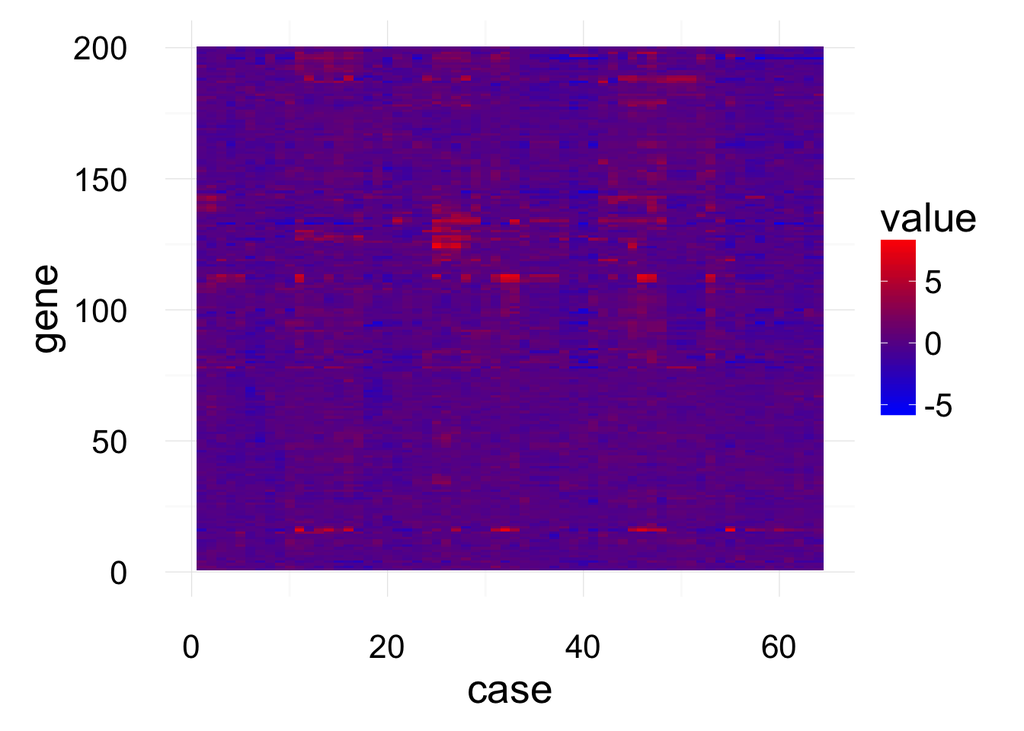

```r
ggplot(aes(y = gene, x = case, fill = value),
  data = nci.long.samp) +
  geom_tile() +
  scale_fill_gradientn(colours = colorRampPalette(c("blue", "red"))(100))
```

### Analyzing Three of More Variables

Reflection: More than two varibles are possible in line plots and using multiple lines in the same plot.

Click **KnitHTML** to see all of your hard work and to have an html page of this lesson, your answers, and your notes!